# 2.1 Continuous Probability

Code: Cumulative distribution function Define x as male heights from the dslabs heights dataset:

```r
library(tidyverse)
library(dslabs)
data(heights)
x <- heights %>% filter(sex=="Male") %>% pull(height)
```

Given a vector x, we can define a function for computing the CDF of x using:

```r
F <- function(a) mean(x <= a)
1 - F(70)    # probability of male taller than 70 inches
```

```
[1] 0.3768473
```

Code: Using pnorm() to calculate probabilities Given male heights x:

```r
library(tidyverse)
library(dslabs)
data(heights)
x <- heights %>% filter(sex=="Male") %>% pull(height)
```

We can estimate the probability that a male is taller than 70.5 inches using:

```r
1 - pnorm(70.5, mean(x), sd(x))
```

```
[1] 0.371369
```

Code: Discretization and the normal approximation

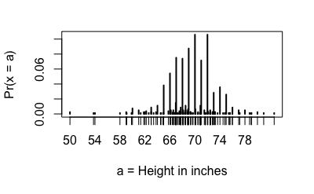

```r
# plot distribution of exact heights in data
plot(prop.table(table(x)), xlab = "a = Height in inches", ylab = "Pr(x = a)")
```

```r
# probabilities in actual data over length 1 ranges containing an integer
mean(x <= 68.5) - mean(x <= 67.5)
```

```
[1] 0.114532
```

```r
mean(x <= 69.5) - mean(x <= 68.5)
```

```
[1] 0.1194581
```

```r
mean(x <= 70.5) - mean(x <= 69.5)
```

```
[1] 0.1219212
```

```r
# probabilities in normal approximation match well
pnorm(68.5, mean(x), sd(x)) - pnorm(67.5, mean(x), sd(x))
```

```
[1] 0.1031077
```

```r
pnorm(69.5, mean(x), sd(x)) - pnorm(68.5, mean(x), sd(x))
```

```
[1] 0.1097121
```

```r
pnorm(70.5, mean(x), sd(x)) - pnorm(69.5, mean(x), sd(x))
```

```
[1] 0.1081743
```

```r
# probabilities in actual data over other ranges don't match normal approx as well
mean(x <= 70.9) - mean(x <= 70.1)
```

```
[1] 0.02216749
```

```r
pnorm(70.9, mean(x), sd(x)) - pnorm(70.1, mean(x), sd(x))
```

```
[1] 0.08359562
```

Plotting the Probability Density

Plotting the probability density for the normal distribution We can use dnorm() to plot the density curve for the normal distribution. dnorm(z) gives the probability density 𝑓(𝑧) of a certain z-score, so we can draw a curve by calculating the density over a range of possible values of z.

First, we generate a series of z-scores covering the typical range of the normal distribution. Since we know 99.7% of observations will be within −3≤𝑧≤3, we can use a value of 𝑧 slightly larger than 3 and this will cover most likely values of the normal distribution. Then, we calculate 𝑓(𝑧), which is dnorm() of the series of z-scores. Last, we plot 𝑧 against 𝑓(𝑧).

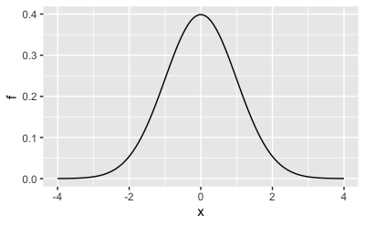

```r
library(tidyverse)
x <- seq(-4, 4, length = 100)
data.frame(x, f = dnorm(x)) %>%
    ggplot(aes(x, f)) +
    geom_line()
```

```r
dnorm(z, mu, sigma)
```

[output not shown]

Code: Generating normally distributed random numbers

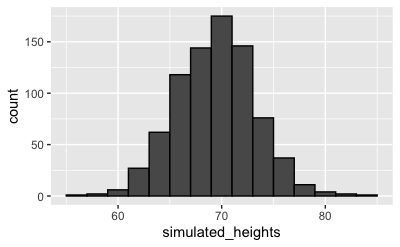

```r
# define x as male heights from dslabs data
library(tidyverse)
library(dslabs)
data(heights)
x <- heights %>% filter(sex=="Male") %>% pull(height)

# generate simulated height data using normal distribution - both datasets should have n observations
n <- length(x)
avg <- mean(x)
s <- sd(x)
simulated_heights <- rnorm(n, avg, s)

# plot distribution of simulated_heights
data.frame(simulated_heights = simulated_heights) %>%
    ggplot(aes(simulated_heights)) +
    geom_histogram(color="black", binwidth = 2)
```

Code: Monte Carlo simulation of tallest person over 7 feet

```r
B <- 10000
tallest <- replicate(B, {
    simulated_data <- rnorm(800, avg, s)    # generate 800 normally distributed random heights
    max(simulated_data)    # determine the tallest height
})
mean(tallest >= 7*12)    # proportion of times that tallest person exceeded 7 feet (84 inches)
```

```
[1] 0.0211
```

Code: Plotting the normal distribution with dnorm Use d to plot the density function of a continuous distribution. Here is the density function for the normal distribution (abbreviation norm()):

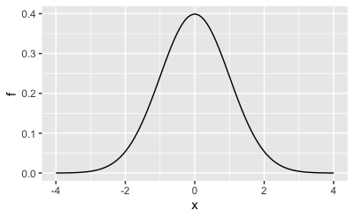

```r
x <- seq(-4, 4, length.out = 100)
data.frame(x, f = dnorm(x)) %>%
    ggplot(aes(x,f)) +
    geom_line()
```